# MY472 - Week 9: Working with Online Databases

November 27, 2018

## Outline

- Database Solution for Big Data
- SQL vs noSQL
- Cloud solutions
  - GCP Bigquery
  - AWS Redshift/DynamoDB
- Examples
  - Mongo DB
  - Google Bigquery

## Big Data

- Your data can be really big
  - Gigabytes? Terabytes? Petabytes or more?
- And also very complicated

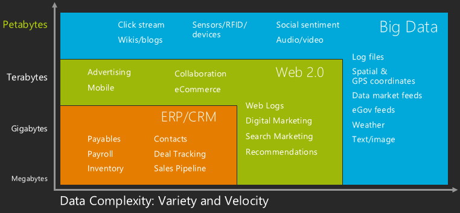

## Database Solutions Big Data

- Different types of databases (SQL vs NoSQL)
- Cloud solution using fully managed services

## SQL or noSQL

## SQL?

**SQL**: **S**tructured **Q**uery **L**anguage

- We have learned how to run query in SQL databases
- Example:

  ```sql
      SELECT name, party FROM congress;
  ```

- SQL databases has a strict structure

## SQL Structure

It’s all about relations

### A simple e-commerce example

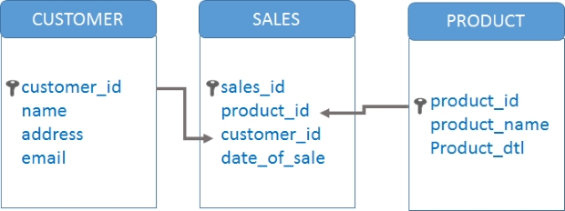

## SQL: Review

- The result of an SQL query is always a table
- There are a number of commands, and many of them are about the relations between tables SELECT columns
  - **FROM** a table in a database
  - **WHERE** rows meet a condition
  - **GROUP** BY values of a column
  - **ORDER** BY values of a column when displaying results
  - **LIMIT** to only X number of rows in resulting table
  - Always required: **SELECT** and **FROM**.
- Rest are optional.
  - **SELECT** can be combined with operators such as **SUM, COUNT, AVG**…
  - To merge multiple tables, you can use **JOIN**

## noSQL

A noSQL (originally referring to “non SQL”, “non relational” or “not only SQL”) database provides a mechanism for storage and retrieval of data which is modeled in means other than the tabular relations used in relational databases.

noSQL databases are good for the data with:

- High data **velocity** – lots of data coming in very quickly
- Data **variety** – data can be structured, semi-structured and unstructured
- Data **volume** - total size of data
- Data **complexity** - stored in many locations

## noSQL: types

[figure not shown]

From: [Simplelern](https://www.simplilearn.com/introduction-to-nosql-databases-tutorial-video)

## noSQL: Pros and Cons

| PROS | CONS |
| --- | --- |
| Massive scalability | Limited query capabilities |
| High availability | Not standardized |
| Schema flexibility | Not matured |
| Sparse and semistructured data | Developer heavy |

## MongoDB

- **Document** based database
- Concept mapping:

| SQL Terms/Concepts | MongoDB Terms/Concepts |
| --- | --- |
| database | database |
| table | collection |
| row | document or BSON document |
| column | field |

- Each document is constructed as a **BSON** (Binary JSON)

## MongoDB documents

A document looks like this:

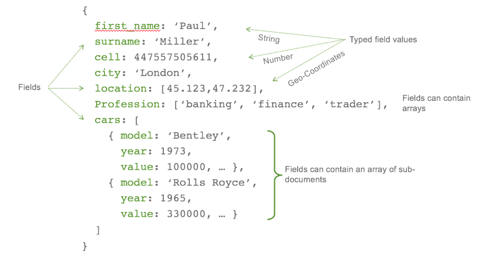

From [datawow.io](https://blog.datawow.io/introduction-to-mongodb-pymongo-e1948ec6b819)

## MongoDB Example

See `mongodb-demo.rmd`

- We will see the replication of SQL Basics in the last week using MongoDB
- For a simple selection of documents (i.e. rows in SQL), we will use `find()` method
- For a bit more sophisticated query, we will use `aggregate()` method
- Search query is in **BSON**
- For your reference, we will see the equivalent syntax of SQL right above the MongoDB query

## MongoDB: JOIN?

- Use **$lookup**

  ```r
    dbMongo$aggregate([
      { "$match": { "party": "Republican" } },
      { "$sort": { "shares_count": -1 } },
      { "$limit": 10 },
      { "$lookup": {
        "localField": "screen_name",
        "from": "congress", "foreignField": "screen_name",
        "as": "congress"
      } }])
  ```

- This is close to

  ```r
  dbGetQuery(db,  "SELECT posts.*, congress.*
    FROM posts JOIN congress ON congress.screen_name = posts.screen_name
    WHERE party = 'Republican'
    ORDER BY shares_count DESC LIMIT 10")
  ```

## MongoDB: JOIN?

- This will work, but it is not as powerful as SQL’s **JOIN**. In the end, “[if you have relational data, use a relational (SQL) database!](https://www.sitepoint.com/using-joins-in-mongodb-nosql-databases/)”.

## Managed services in the cloud

## Services

| Database Type | AWS | GCP | Azure |
| --- | --- | --- | --- |
| Managed RDS | Amazon RDS | Cloud SQL | Azure SQL |
| Data Warehousing | Redshift | Bigquery | Snowflake |
| NoSQL (simple key-value) | DynamoDB | BigTable | Azure Tables |
| NoSQL (document) | MongoDB on EC2 | MongoDB on GCE | DocumentDB |

## Google Cloud Platform: Bigquery

- GCP’s data warehousing
- Integration with other Google data storage solutions (Google Drive, Google Cloud Storage)
- Scalable: same SQL syntax for datasets of *any* size
- Easy to collaborate and export results
- Affordable pricing and cost control
- API access allows integration with R or python
- Excellent documentation

## Bigquery pricing

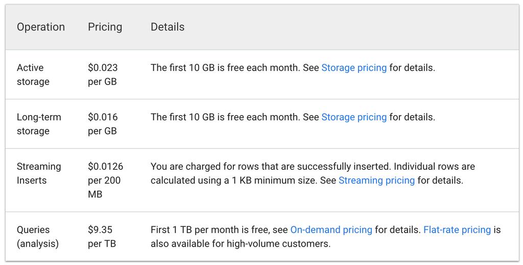

## Bigquery example

- `Bigquery-demo.rmd`

## This week’s lab

- SQL topics: JOINs and sub queries
- Problem Set 8 (Assessed Assignment #4)